# Heart Disease Classification in R

Mitali Patle

## Exploratory analysis

```r
# Creating a summary table for the   HeartDisease variable.
Heart_Disease_Data %>%
  count(HeartDisease) %>%
  mutate(prop=round(prop.table(n),3), pct=round(prop.table(n),3)*100) %>%
  kable() %>%
  kable_styling()
```

| HeartDisease | n | prop | pct |
| --- | --- | --- | --- |
| No | 1503 | 0.277 | 27.7 |
| Yes | 3917 | 0.723 | 72.3 |

An uneven distribution of Class 1(`No`)and Class 2(`Yes`)can be observed. Approx. 28% of observations in Class1(`No`) and Approx 72% of observations in class 2(`Yes`).This shows imbalance between the classes which can be handled by logistic regression very well.

Creating box plots of(quantitative) BMI,PhysicalHealth, MentalHealth ,SleepTime variables by HeartDisease.

## Exploratory plots

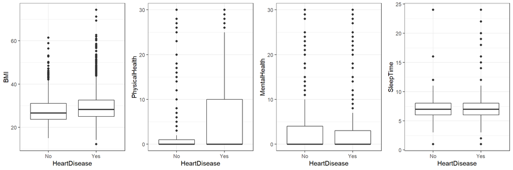

The box plots of BMI and SleepTime looks fairly symmetric as the median lie on the middle of the box plots whereas asymmetrical plots can be observed for PhysicalHealth and MentalHealth variable with the median on the lower end of the box .Numerous outlying values are present on the tails of variables.

Creating summary statistics of each quantitative variable to get a better understanding of the useful predictor of Heart Disease.

```
## [1] "BMI"
```

| HeartDisease | min | max | Q1 | median | Q3 | mean | sd |
| --- | --- | --- | --- | --- | --- | --- | --- |
| No | 15.00 | 61.44 | 23.69 | 26.63 | 31.055 | 27.99293 | 6.070109 |
| Yes | 12.21 | 74.33 | 25.06 | 28.27 | 32.550 | 29.36161 | 6.443873 |

```
## [1] "PhysicalHealth"
```

| HeartDisease | min | max | Q1 | median | Q3 | mean | sd |
| --- | --- | --- | --- | --- | --- | --- | --- |
| No | 0 | 30 | 0 | 0 | 1 | 2.869594 | 7.219889 |
| Yes | 0 | 30 | 0 | 0 | 10 | 7.391882 | 11.268674 |

```
## [1] "MentalHealth"
```

| HeartDisease | min | max | Q1 | median | Q3 | mean | sd |
| --- | --- | --- | --- | --- | --- | --- | --- |
| No | 0 | 30 | 0 | 0 | 4 | 3.971391 | 8.011384 |
| Yes | 0 | 30 | 0 | 0 | 3 | 4.454940 | 9.005748 |

```
## [1] "SleepTime"
```

| HeartDisease | min | max | Q1 | median | Q3 | mean | sd |
| --- | --- | --- | --- | --- | --- | --- | --- |
| No | 1 | 24 | 6 | 7 | 8 | 7.067864 | 1.381126 |
| Yes | 1 | 24 | 6 | 7 | 8 | 7.076079 | 1.782142 |

From the plots and summary statistics BMI appears to have the largest difference (difference in medians = 1.64 approx.) between the two classes so might be an important factor to influence HeartDisease.

Creating cross tabulation and bar charts between categorical variables to understand the relationship between Smoking, AlcoholDrinking, Stroke, Sex, AgeCategory variables by HeartDisease

```
##             Smoking
## HeartDisease   No  Yes
##          No   908  595
##          Yes 1620 2297
```

```
##             AlcoholDrinking
## HeartDisease   No  Yes
##          No  1378  125
##          Yes 3744  173
```

```
##             Stroke
## HeartDisease   No  Yes
##          No  1465   38
##          Yes 3278  639
```

```
##             Sex
## HeartDisease Female Male
##          No     798  705
##          Yes   1639 2278
```

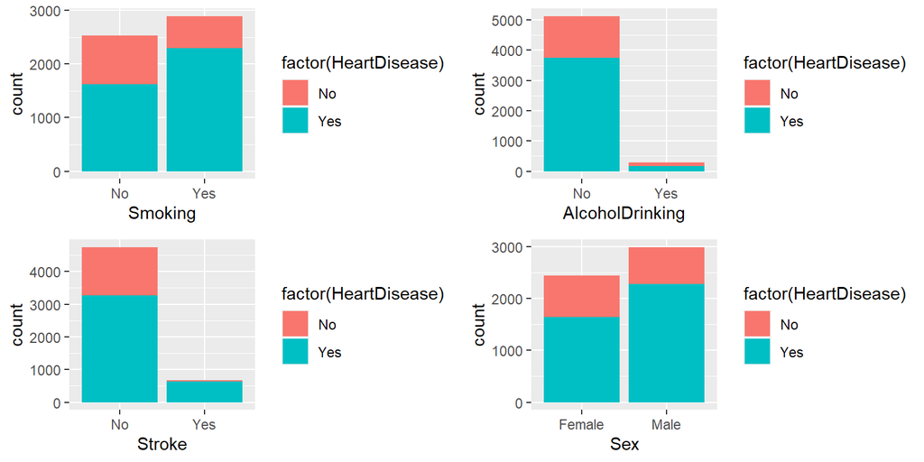

```
##             AgeCategory
## HeartDisease 18-24 25-29 30-34 35-39 40-44 45-49 50-54 55-59 60-64 65-69 70-74
##          No    107    83   101   106   111   117   121   139   148   155   148
##          Yes    14    21    33    54    73    99   197   358   469   556   706
##             AgeCategory
## HeartDisease 75-79 80 or older
##          No     80          87
##          Yes   574         763
```

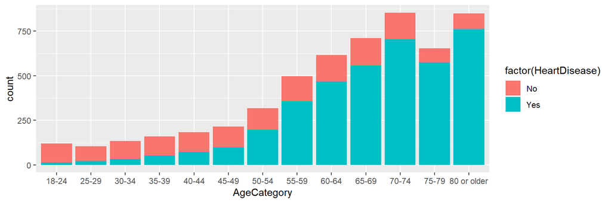

From the above bar charts and cross tabulation the distribution of categorical variables by Heart Disease can be observed.Some of the interesting insights drawn from the data are as follows:

## Correlation(to check multicollinearity between variables X’s in the data)

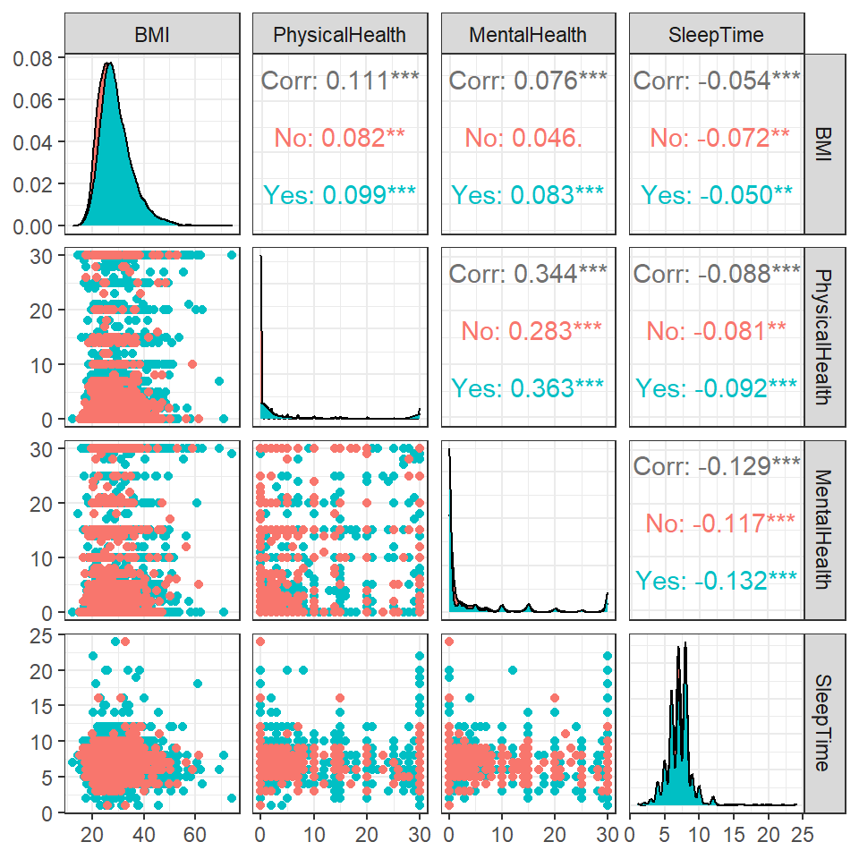

```r
ggpairs(data = Heart_Disease_Data %>% dplyr::select(where(is.numeric)), ggplot2::aes(colour=Heart_Disease_Data$HeartDisease),upper = list(continuous = wrap(ggally_cor))) + theme_bw()
```

Minimal correlation found between quantitative variables which indicates there is little evidence of multi-collinearity between these variables.There can be seen a weak positive correlation between Physical and Mental Health (r=0.344).

## Formal analysis

### (A) Fitting the logistic model

```r
glm.fit = glm(HeartDisease ~ BMI+ PhysicalHealth+MentalHealth +SleepTime+ Smoking + AlcoholDrinking + Stroke + Sex + AgeCategory, data=Heart_Disease_Data, family="binomial")

summary(glm.fit)
```

```
##
## Call:
## glm(formula = HeartDisease ~ BMI + PhysicalHealth + MentalHealth +
##     SleepTime + Smoking + AlcoholDrinking + Stroke + Sex + AgeCategory,
##     family = "binomial", data = Heart_Disease_Data)
##
## Deviance Residuals:
##     Min       1Q   Median       3Q      Max
## -3.2167  -0.5354   0.4477   0.6864   2.4316
##
## Coefficients:
##                         Estimate Std. Error z value Pr(>|z|)
## (Intercept)            -3.603079   0.385988  -9.335  < 2e-16 ***
## BMI                     0.045968   0.006153   7.471 7.96e-14 ***
## PhysicalHealth          0.036624   0.004626   7.917 2.43e-15 ***
## MentalHealth            0.015116   0.004946   3.056 0.002241 **
## SleepTime              -0.057022   0.022958  -2.484 0.013002 *
## SmokingYes              0.542514   0.073734   7.358 1.87e-13 ***
## AlcoholDrinkingYes     -0.492916   0.148932  -3.310 0.000934 ***
## StrokeYes               1.696171   0.180869   9.378  < 2e-16 ***
## SexMale                 0.641028   0.073979   8.665  < 2e-16 ***
## AgeCategory25-29        0.488883   0.392249   1.246 0.212632
## AgeCategory30-34        0.577639   0.366270   1.577 0.114776
## AgeCategory35-39        1.011814   0.348554   2.903 0.003697 **
## AgeCategory40-44        1.209504   0.339770   3.560 0.000371 ***
## AgeCategory45-49        1.368127   0.334315   4.092 4.27e-05 ***
## AgeCategory50-54        2.095564   0.322394   6.500 8.03e-11 ***
## AgeCategory55-59        2.549408   0.316028   8.067 7.20e-16 ***
## AgeCategory60-64        2.765321   0.313430   8.823  < 2e-16 ***
## AgeCategory65-69        3.005873   0.312235   9.627  < 2e-16 ***
## AgeCategory70-74        3.361447   0.312405  10.760  < 2e-16 ***
## AgeCategory75-79        3.736930   0.322722  11.579  < 2e-16 ***
## AgeCategory80 or older  4.205473   0.320935  13.104  < 2e-16 ***
## ---
## Signif. codes:  0 '***' 0.001 '**' 0.01 '*' 0.05 '.' 0.1 ' ' 1
##
## (Dispersion parameter for binomial family taken to be 1)
##
##     Null deviance: 6399.8  on 5419  degrees of freedom
## Residual deviance: 4808.4  on 5399  degrees of freedom
## AIC: 4850.4
##
## Number of Fisher Scoring iterations: 5
```

```r
round(exp(cbind(OR = coef(glm.fit), confint(glm.fit))),3)
```

```
##                            OR  2.5 %  97.5 %
## (Intercept)             0.027  0.012   0.057
## BMI                     1.047  1.035   1.060
## PhysicalHealth          1.037  1.028   1.047
## MentalHealth            1.015  1.006   1.025
## SleepTime               0.945  0.903   0.988
## SmokingYes              1.720  1.489   1.988
## AlcoholDrinkingYes      0.611  0.457   0.819
## StrokeYes               5.453  3.877   7.892
## SexMale                 1.898  1.643   2.195
## AgeCategory25-29        1.630  0.762   3.578
## AgeCategory30-34        1.782  0.883   3.744
## AgeCategory35-39        2.751  1.420   5.611
## AgeCategory40-44        3.352  1.765   6.735
## AgeCategory45-49        3.928  2.093   7.820
## AgeCategory50-54        8.130  4.448  15.860
## AgeCategory55-59       12.800  7.101  24.696
## AgeCategory60-64       15.884  8.862  30.509
## AgeCategory65-69       20.204 11.302  38.728
## AgeCategory70-74       28.831 16.124  55.287
## AgeCategory75-79       41.969 22.973  81.983
## AgeCategory80 or older 67.052 36.845 130.574
```

From the summary of the model ,it can be seen that all the variable except AgeCategory 25-29 and AgeCategory 30-34 have very small p values that are much less than 0.05 indicating that they are statistically significant.

Sleep Time and being a heavy alcohol drinker (AlchoholDrinkingYes) shows negative coefficient values -0.057 and -0.492 respectively ,indicating increasing sleep time will decrease the chances of person having a heart disease. Similarly,heavy alcohol drinker are less likely to have heart disease than light/non alcoholic drinkers(AlchoholDrinkingNo).i.e, being a heavy drinker lowers the odds of having a heart disease.

BMI,PhysicalHealth,MentalHealth,SmokingYes,StrokeYes,SexMale,all Age Categories(above 34) have positive coefficient indicating higher value of BMI,Higher number of past unhealthy days physically and mentally increases the chance of having a heart disease likewise being smoker, had a stroke before and falling in an age category above 34 increase the chances of having a heart disease.

```r
#Confusion matrix and classification rate)

pred.probs = predict(glm.fit, type = "response")

pred.probs[1:12]
```

```
##          1          2          3          4          5          6          7
## 0.67439749 0.64194735 0.80734838 0.75820331 0.78667202 0.82730842 0.53710660
##          8          9         10         11         12
## 0.85176152 0.95485353 0.08361718 0.75273248 0.63100186
```

```r
pred.class = ifelse(pred.probs > 0.5, "Yes", "No")

table(pred.class, Heart_Disease_Data$HeartDisease)
```

```
##
## pred.class   No  Yes
##        No   708  235
##        Yes  795 3682
```

```r
mean(pred.class ==Heart_Disease_Data$ HeartDisease)
```

```
## [1] 0.8099631
```

81% of observations are correctly classified and the training error rate is 19%. The logistic regression model is performing very well but this could be due to the fact that same data used for training and testing.

```r
#Fitting the model with training data(accounting 70% of the total data)
glm.fit.train<- glm(HeartDisease ~ BMI+ PhysicalHealth+MentalHealth +SleepTime+ Smoking + AlcoholDrinking + Stroke + Sex + AgeCategory, data=train, family="binomial")

summary(glm.fit.train)
```

```
##
## Call:
## glm(formula = HeartDisease ~ BMI + PhysicalHealth + MentalHealth +
##     SleepTime + Smoking + AlcoholDrinking + Stroke + Sex + AgeCategory,
##     family = "binomial", data = train)
##
## Deviance Residuals:
##     Min       1Q   Median       3Q      Max
## -3.2950  -0.5323   0.4470   0.6936   2.5003
##
## Coefficients:
##                         Estimate Std. Error z value Pr(>|z|)
## (Intercept)            -3.625840   0.484244  -7.488 7.01e-14 ***
## BMI                     0.049953   0.007327   6.818 9.24e-12 ***
## PhysicalHealth          0.037058   0.005502   6.735 1.64e-11 ***
## MentalHealth            0.015430   0.006006   2.569  0.01020 *
## SleepTime              -0.091023   0.028604  -3.182  0.00146 **
## SmokingYes              0.450467   0.088614   5.083 3.71e-07 ***
## AlcoholDrinkingYes     -0.450447   0.180540  -2.495  0.01260 *
## StrokeYes               1.860261   0.225652   8.244  < 2e-16 ***
## SexMale                 0.668747   0.088586   7.549 4.38e-14 ***
## AgeCategory25-29        0.703198   0.492389   1.428  0.15325
## AgeCategory30-34        0.831954   0.461763   1.802  0.07159 .
## AgeCategory35-39        1.161142   0.446976   2.598  0.00938 **
## AgeCategory40-44        1.319623   0.434571   3.037  0.00239 **
## AgeCategory45-49        1.405475   0.428842   3.277  0.00105 **
## AgeCategory50-54        2.391129   0.417074   5.733 9.86e-09 ***
## AgeCategory55-59        2.689682   0.409333   6.571 5.00e-11 ***
## AgeCategory60-64        2.874145   0.406876   7.064 1.62e-12 ***
## AgeCategory65-69        3.179155   0.404917   7.851 4.12e-15 ***
## AgeCategory70-74        3.572288   0.405753   8.804  < 2e-16 ***
## AgeCategory75-79        3.913035   0.417747   9.367  < 2e-16 ***
## AgeCategory80 or older  4.323064   0.413895  10.445  < 2e-16 ***
## ---
## Signif. codes:  0 '***' 0.001 '**' 0.01 '*' 0.05 '.' 0.1 ' ' 1
##
## (Dispersion parameter for binomial family taken to be 1)
##
##     Null deviance: 4479.7  on 3793  degrees of freedom
## Residual deviance: 3364.7  on 3773  degrees of freedom
## AIC: 3406.7
##
## Number of Fisher Scoring iterations: 5
```

The summary of the model fitted with training data shows the similar statistical significance of variables as shown previously.

```r
pred.probs.test = predict(glm.fit.train,test,type = "response")

pred.class.test = ifelse(pred.probs.test > 0.5, "Yes", "No")

mean(pred.class.test ==Heart_Disease_Data$ HeartDisease)
```

```
## [1] 0.6625461
```

On Prediction with the test data(accounting 30% of the total data)for the fitted model with train data, classification rate reduced to 66% which is still performing better than random guessing.

### (B) Fitting the Decision Classification Tree model

```r
#model building using training data
tree.HeartDisease=tree(HeartDisease~.,data=Heart_Disease_Data)
summary(tree.HeartDisease)
```

```
##
## Classification tree:
## tree(formula = HeartDisease ~ ., data = Heart_Disease_Data)
## Variables actually used in tree construction:
## [1] "AgeCategory"    "PhysicalHealth" "Stroke"
## Number of terminal nodes:  6
## Residual mean deviance:  0.9567 = 5180 / 5414
## Misclassification error rate: 0.2065 = 1119 / 5420
```

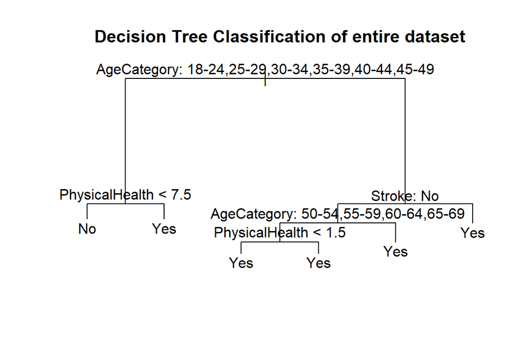

```r
#plotting the model that is trained using entire HeartDisease data
plot(tree.HeartDisease)
text(tree.HeartDisease, pretty = 0)
title(main = "Decision Tree Classification of entire dataset")
```

```r
tree.HeartDisease
```

```
## node), split, n, deviance, yval, (yprob)
##       * denotes terminal node
##
##  1) root 5420 6400.0 Yes ( 0.27731 0.72269 )
##    2) AgeCategory: 18-24,25-29,30-34,35-39,40-44,45-49 919 1152.0 No ( 0.68009 0.31991 )
##      4) PhysicalHealth < 7.5 780  883.8 No ( 0.74615 0.25385 ) *
##      5) PhysicalHealth > 7.5 139  172.0 Yes ( 0.30935 0.69065 ) *
##    3) AgeCategory: 50-54,55-59,60-64,65-69,70-74,75-79,80 or older 4501 4442.0 Yes ( 0.19507 0.80493 )
##      6) Stroke: No 3883 4074.0 Yes ( 0.21813 0.78187 )
##       12) AgeCategory: 50-54,55-59,60-64,65-69 1868 2261.0 Yes ( 0.29336 0.70664 )
##         24) PhysicalHealth < 1.5 1133 1488.0 Yes ( 0.36540 0.63460 ) *
##         25) PhysicalHealth > 1.5 735  698.1 Yes ( 0.18231 0.81769 ) *
##       13) AgeCategory: 70-74,75-79,80 or older 2015 1692.0 Yes ( 0.14839 0.85161 ) *
##      7) Stroke: Yes 618  246.0 Yes ( 0.05016 0.94984 ) *
```

```r
#model building using training data
tree.HeartDisease.train = tree(HeartDisease~.,data=train)
summary(tree.HeartDisease.train)
```

```
##
## Classification tree:
## tree(formula = HeartDisease ~ ., data = train)
## Variables actually used in tree construction:
## [1] "AgeCategory"    "PhysicalHealth" "Stroke"
## Number of terminal nodes:  5
## Residual mean deviance:  0.9689 = 3671 / 3789
## Misclassification error rate: 0.2066 = 784 / 3794
```

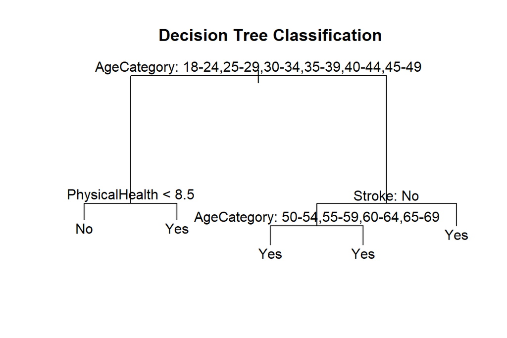

```r
#plotting the model that is trained using training data
plot(tree.HeartDisease.train)
text(tree.HeartDisease.train, pretty = 0)
title(main = "Decision Tree Classification")
```

The plots of complete data and training data shows how Decision Tree classification is sensitive towards change in data.For example-The branching criteria changes for PhysicalHealth from 7.5(Complete data) to 8.5(Training Data).

```r
#prediction using train data
tree.HeartDisease.pred.train=predict(tree.HeartDisease.train,train,type="class")
cat("Training data classification rate=",mean(train$HeartDisease ==tree.HeartDisease.pred.train))
```

```
## Training data classification rate= 0.7933579
```

```r
#prediction using test data
tree.HeartDisease.pred=predict(tree.HeartDisease.train,test,type="class")
cat("\nTesting  data classification rate=",mean(test$HeartDisease ==tree.HeartDisease.pred))
```

```
##
## Testing  data classification rate= 0.7933579
```

Training error rate is 21%.Classification rate was found to be: Training data classification rate= 0.7933579(79.3%) Testing data classification rate = 0.7933579(79.3%). The results are much better than random guessing.

## Conclusions

On fitting the model using Logistic regression and Decision Tree classification,the classification rate obtained are approximately 66% and 79% respectively.This shows that Decision Tree classification model is performing better than logistic regression model on test data.

The graphical representation of the tree model was easier to interpret as compared to coefficients or log odds obtained from logistic regression.

## (b) - Non-technical report

Two Classification approaches are used to determine the factors that influence whether a person has heart disease or not.

The prediction model built through the logistic method was found to have an accuracy of 81% which tells us we are 81% sure that the prediction made about having heart disease or not is true but this accuracy was achieved because the same data was used for the prediction which was used to build the model as well but in reality, new data is always unseen.

Thus data were divided into 2 parts known as training data and testing data. Again a new model was built using training data and the unseen testing data is used to measure the accuracy of the model which was found to be 66% but is still better than random guessing.

B).In the Decision Tree Classification approach, a model similar to logistic regression was built but using the tree approach. In summarizing the model, the misclassification error rate was found to be 21%. i.e the proportion of data that was incorrectly classified into another class. For example, the data which was supposed to be allocated to(`yes`) was mistakenly classified into (`No`) and vice versa.

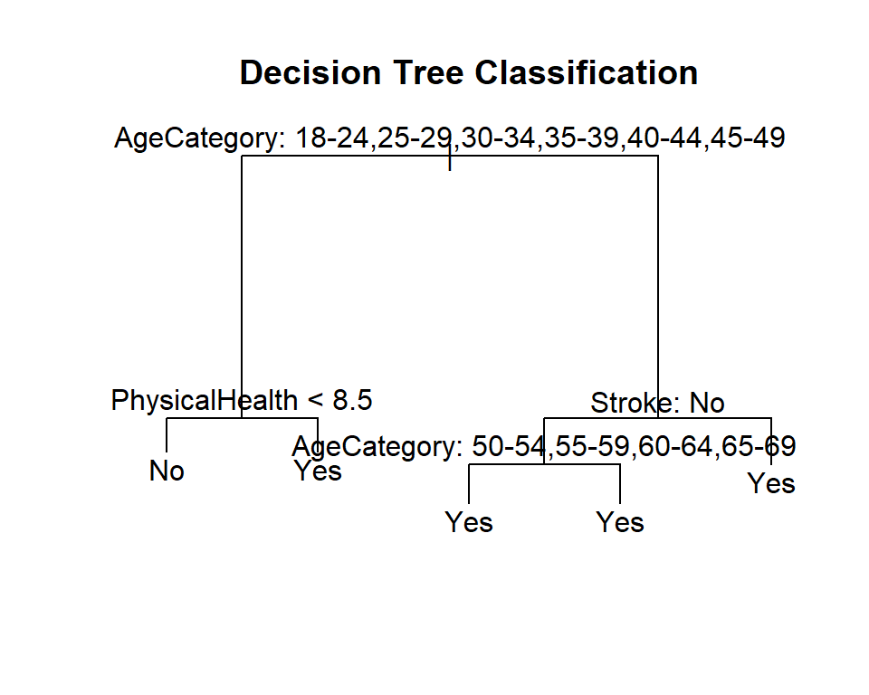

The most important factor to determine if a person has heart disease or not appears to be Age Category, since the first branch differentiates AgeCategory 18 to 49 years from the rest of the Age Group factors. The same training and testing data that were used previously were utilized to check the prediction accuracy of this model where training data is used in building the model and testing data to find the accuracy which was found to be approximately 79%.

Both the analysis approach performed better than average or a random guess but it can be clearly seen that the Decision tree has out-performed the logistic regression function when the unseen data was used to do the prediction of Heart Disease in a person.